# Matching estimators and flooding

Leon Stirk-Wang

7/31/2019

## Intro

On the 4th of June 2015 South Dunedin experienced a flooding event. At the time, news outlets reported that 400 emergency call were made regarding the flooding, and that the army, firefighters, and volunteers had sandbagged around 100 houses. Later measurements of surface ponding depth indicated a significant amount of ponding of up to 30 centimetres in depth over the approximately 2.5 square kilometres that were worst affected. A smaller number of measurements were significantly higher with some measurements in the range of 50 to 60 centimetres of ponding above ground level.

The effects of the weather event that that precipitated the flooding event were not limited to South Dunedin. The heavy rain caused slips that necessitated the closure of roads. Several schools were evacuated and there was a significant threat to property in the surrounding semi-rural areas built on the floodplain of the Taieri river. However, it is specifically the flooding in South Dunedin, rather than the more widespread effects of the severe weather event, that is of primary interest in this paper.

The analysis presented in this paper examines the Dunedin real-estate market and produces estimates of the impact of the 2015 flooding event on residential property prices. The intention is to provide an understanding of the market response to natural hazard risk and changing information about those risks in the face of a destructive event.

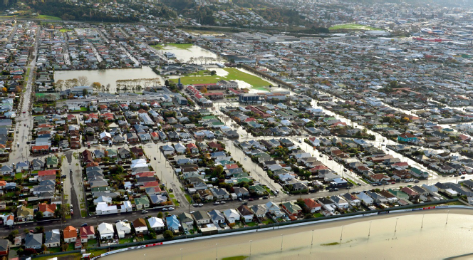

Dunedin is of special interest with respect to flood risks. It is a city located at the southern end of the South Island of New Zealand. It is the principal city of the Otago region and the second most populous city in the South Island. As of June 2018 the urban area was estimated to be home to around 122,000 people.

Dunedin has around 2700 residences located within 50 centimetres of the spring high-tide mark. This is higher than any other city in New Zealand and represents a not insignificant proportion of the residential housing stock. These houses face the most immediate risk of inundation due to sea-level rise. The threat of inundation is not one that can be considered in isolation. Rising average global temperatures will not only increase the ground-water level via sea-level rise but will increase the frequency and severity of weather events. The combination of these effects will compound the risks to low-lying properties. The most-recent experience of flooding events are a sobering reminder of this. Most of the properties identified as being at the greatest risk are located on the South Dunedin plain.

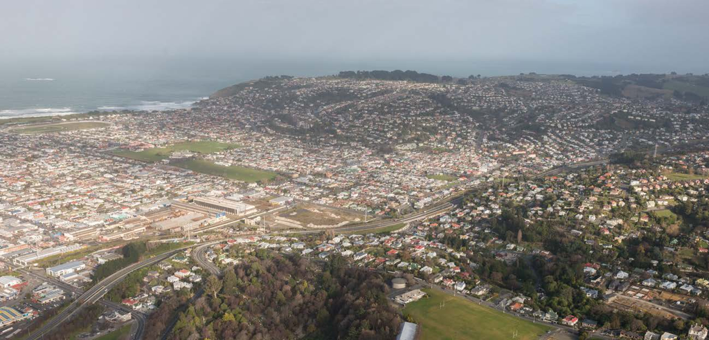

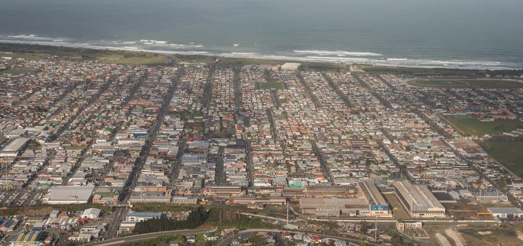

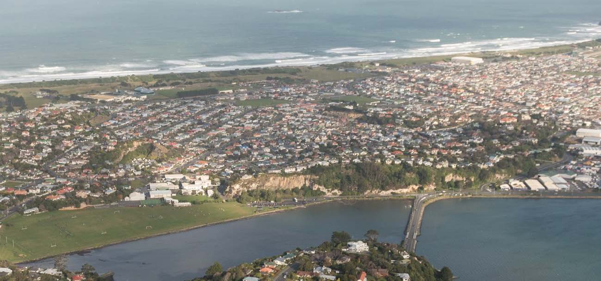

Geologically, the South Dunedin plain was formed in the last glacial period when the sea-level was significantly lower than it is now. Beneath the plain is a valley of volcanic bedrock. During this glacial period the catchment area that is now the Otago harbour drained through this valley out toward the coast depositing sands, silts, and gravels along the valley bed. As the sea rose to its current level, these sands, silts, and gravels consolidated in the valley to form a relatively flat plain. Prior to European settlement, the area of land on this plain that was suitable to be built upon was considerably smaller than it is today. The spring-high tide mark on both the harbour side and to the south extended significantly further inland than the present day coastline. There were large areas of wetland in what are now the suburbs of Musselburgh and St Kilda that drained into a saltwater lagoon inland of the modern high tide mark.

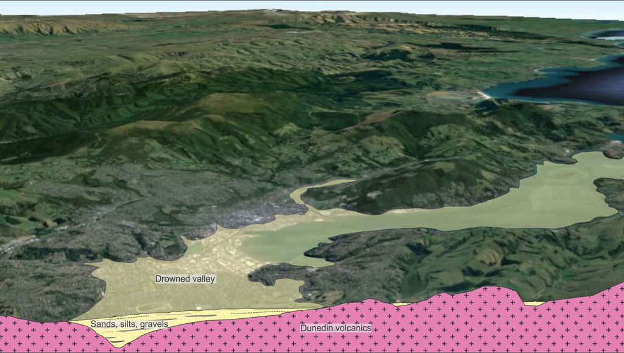

[figure not shown]

[figure not shown]

The mid to late 19th century saw a period of rapid settlement by Europeans. The demand for dry land saw the settlers undertake land reclamation activities. This largely consisted of filling in wet, marshy, or low areas with any available infill material. This included sand that was mined from the nearby coastal dunes. Although early reclamation efforts centred around the shoreline of the harbour, these eventually extended further south to what are modern day residential areas. Early reclamation efforts reflect the level of the groundwater at the time which was up to 17cm lower than the present day level. Subsequent infilling in the 1960’s and 70’s of the harbour-side waterfront with dredge spoil raised the ground level in the area between Portsmouth Drive and Andersons Bay Road to a sufficient degree that the present-day groundwater level is not problematic. However, the ground level of the majority of the South Dunedin plain, comprised mostly of residential properties, remains unchanged since the reclamation activities of the mid to late 1800’s.

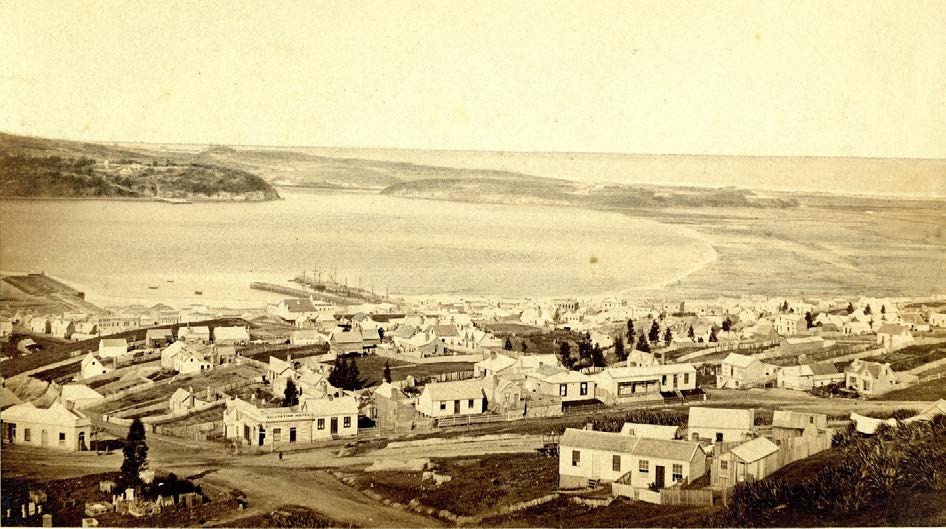

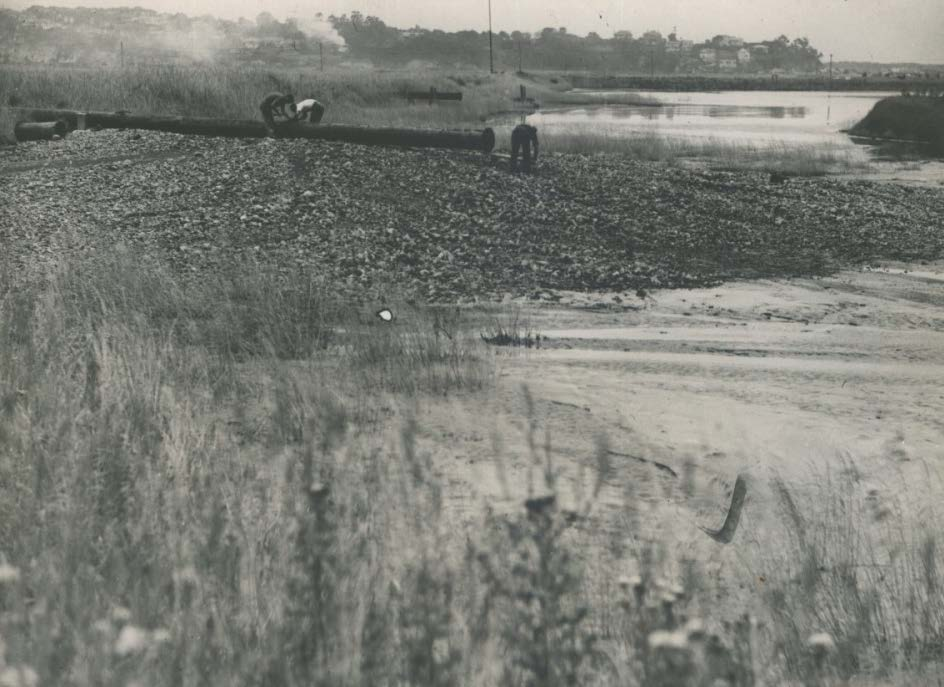

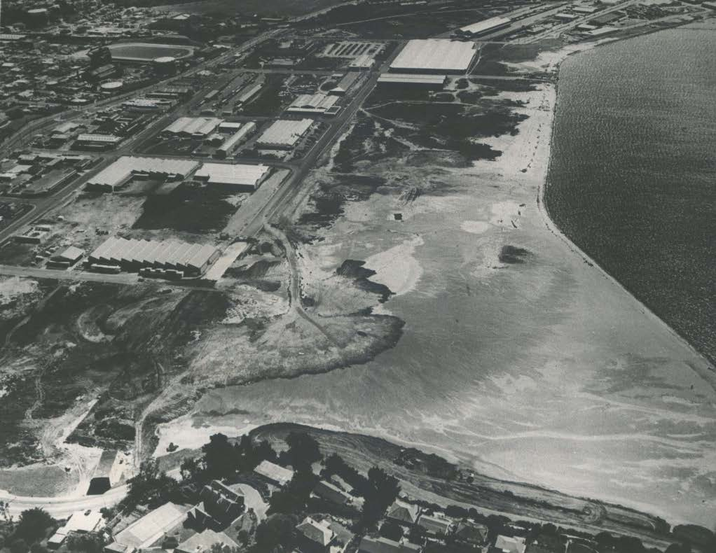

Today, South Dunedin plain has a mix of residential commercial and industrial zoning although the bulk of the plain, and indeed the areas worst affected were primarily residential. For administrative purposes the plain is split into several area units. Area units (or ‘census area units’) are a standard, intermediate administrative unit used by local and state government institutions that represent what might commonly be referred to as a ‘suburb’. Each area unit is comprised of even smaller administrative units known as meshblocks. Meshblocks are the smallest administrative unit of aggregation and are typically comprised of a couple of dozen houses. Commonly the boundaries will run along roads. These might be thought of as small ‘neigbourhoods’ but this is perhaps a less than ideal analogue.

During the June 2015 flooding event only part of the South Dunedin plain was seriously affected. Other areas experienced little to no inundation. This is despite the fact that almost the entirety of the plain has an elevation fairly uniformly within 1 metre of the mean sea-level. Here the mean-sea level might be considered a reasonable if imperfect proxy for the groundwater level. And, at least anecdotally, the uniform ‘low-lyingness’ of the plain as a whole is a proxy for the level of flood risk as might be perceived by real-estate market participants. That is, we might reasonably expect that prospective purchasers of residential properties on the South Dunedin plain to consider the flood risk to all properties with the same elevation above the mean sea-level to be approximately equal either over the long term or in the absence of any additional information (such as the kind provided by a flooding event).

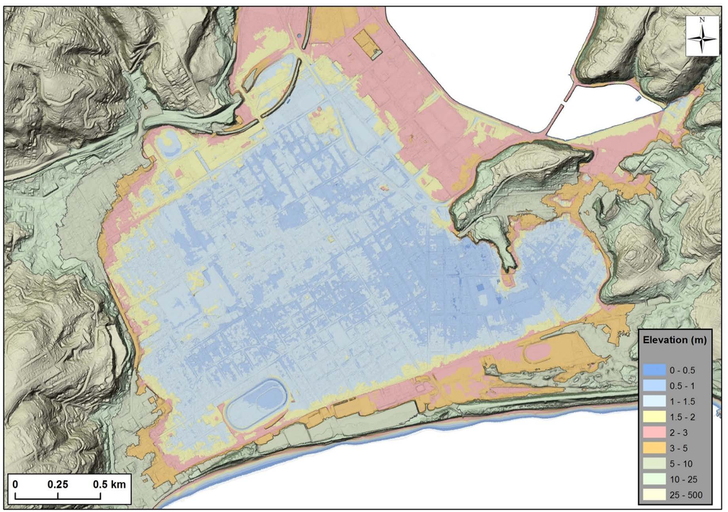

This expectation, coupled with the non-uniform distribution of inundation resulting from the June 2015 flood forms the basis for understanding the results in this analysis as being those of a ‘natural experiment’. Specifically, this analysis presents the results of three questions asked of the natural experiment. Those questions are as follows:

> *(1)* How did the real-estate market in Dunedin price flood risks prior to the June 2015 flood?

> *(2)* Did the price of those risks change in response to the flood?

> *(3)* Did the spatial distribution of flood-risk prices change in response to the flood?

Further, this paper makes one contribution. That is, to show the magnitude to which the estimation of these results is model dependent. At each stage of the analysis, this paper will compare the results of standard regression methods with those of ‘matching estimators’. Matching estimators are an increasingly common technique used for causal inference in observational studies of treatment effects. Simply put, they are a way of matching treated and non-treated units of observation based on their observed characteristics in order to improve estimates of the causal effect of the treatment. The intention is to replicate as closely as possible the conditions of a randomised controlled experiment given the limitations of observational data. The benefit being that the regression is required to do less ‘work’ when estimating the effect of the treatment. The coefficients estimated in the regression are therefore less sensitive to model misspecification.

All of the above questions are addressed in the substantive portion of this paper with each building on the results of the last. That is, the question as to the whether there is a change in the spatial distribution of the ‘flood discount’ is premised on there being a change in the ‘flood discount’ as a result of the 2015 flood event. In turn, the ability to perceive a change in the flood discount requires a baseline measurement of the existing price of flood risk on the South Dunedin plain prior to the flood. Because it is the changes in relative flood-risk price (with respect to location) that are of interest, a natural modelling choice is the difference-in-differences (DiD) approach. The analysis of the final question posed above is presented as the results of an (incomplete) difference-in-difference-in-differences regression. The specific details of the modelling will be explained in further detail in the substantive portion of the paper.

## Some brief comments on approach

The analysis is carried out on a dataset comprised of all residential property transactions occurring in the period January 2000 to September 2018. The unit of observation is a single transaction on a residential property. The same property can therefore appear multiple times in the data set if it has changed hands more than once in the sample period.

With respect to the three questions above, this paper tests for the effect of the flood event, and the effect of location. This paper characterises these as a set of binary variables, or ‘treatments’. The flood event is a treatment with respect to the dimension of time. A transaction occuring before the flood takes the value 0, a transaction occuring after the flood takes the value 1.

The variable that defines the ‘post-flood event’ treatment is as follows:

$$\begin{equation}
after\_flood = \left \{
\begin{array}{c c}
0: & before\ flood \\
1: & after\ flood \\
\end{array}
\right \}
\end{equation}$$

The location of properties can be thought of as a spatial treatment. This paper considers four categories of location. The first category are transactions on properties that would not be considered particularly prone to flooding. Given the geographic history of Dunedin summarised briefly above, this was defined as all those properties which did not lie on the South Dunedin plain. For most of the models considered in this paper, this is the ‘control’ group. The second locational category is defined as the transactions on properties which might have been considered at risk of flooding (prior to the flood). This is defined as the set of properties on the South Dunedin plain (broadly, the complement of the first group).

The paper further decomposes this second category into two subsets that are also considered ‘treatment’ groups. the first of these is the set of properties within the South Dunedin plain that, in fact, experienced some significant inundation in the June 2015 flood. The other group is the complement of the first, the properties which are located on the South Dunedin plain but did not experience inundation.

There were no properties located outside the South Dunedin plain that experienced inundation. For the purpose of this study there are three unique (non-intersecting) groups that will be referred to as the: ‘flooded’ (located on the South Dunedin plain and experienced inundation), ‘not flooded’ (on the South Dunedin plain and did not experience inundation), and ‘not flood prone’ (outside the South Dunedin plain) groups. What will be referred to as the flood prone group (located on the South Dunedin plain) is simply the union of the sets of ‘flooded’ and ‘not flooded’ properties.

The variables that will be used to define the location treatments in the modelling are given below.

$$\begin{aligned}
not\_flood\_prone &= \left \{
\begin{array}{c c}
1: & \textbf{not}\ located\ on\ the\ South\ Dunedin\ plain \\
0: & all\ other\ properties \\
\end{array}
\right \}
\\\\
flood\_prone &= \left \{
\begin{array}{c c}
1: & located\ on\ the\ South\ Dunedin\ plain \\
0: & all\ other\ properties \\
\end{array}
\right \}
\\\\
flooded &= \left \{
\begin{array}{c c}
1: & located\ on\ the\ South\ Dunedin\ plain\ \textbf{and did}\ experience\ inundation\\
0: & all\ other\ properties \\
\end{array}
\right \}
\\\\
not\_flooded &= \left \{
\begin{array}{c c}
1: & located\ on\ the\ South\ Dunedin\ plain\ \textbf{and did not}\ experience\ inundation \\
0: & all\ other\ properties \\
\end{array}
\right \}
\end{aligned}$$

In general, then, the independent variables of interest are some combination of the flood-related treatments (with respect to time or location). And the response variable is, of course, price.

The gold standard in experimental design, whenever a researcher is interested in the causal effects of treatments, is the randomised control trial. A randomised contol trial is an experimental design method where the researcher collects a random sample of units, and randomly assigns each to either the treatment or control group. It is generally accepted that the effect of the treatment that is subsequently observed is a causal one. The core principle is that by randomising the treatment across the sample, the researcher will, by the law of large numbers, have eliminated any correlation between the treatment and either observed or unobserved characteristics across the treatment and control groups.

The randomised control trial design however, requires the ability to randomly assign units of observation to the treatment and control groups over a given sample. Unfortunately, outside of a laboratory environment, it is unusual for observational data (of the sort used in econometric studies) to satisfy this requirement. The assignment of units to treatment or control groups is usually outside of the control of the researcher. And even in cases where the data can be thought of as a ‘natural experiment’ the treatment is usually less than completely random.

Without the ability to design a randomised control experiment. The researcher makes use of other tools to determine causality. Arguably the most common of these is some form of least squares regression. By controlling for the variation in the response variable associated with variations in independent variables that are not of interest, the researcher can isolate the effect of the independent variable of interest on the dependent variable.

It is well established that this kind of analysis is prone to error. The source of error that this paper is primarily concerned with is model misspecification error. Model misspecification error can arise where there is misspecified functional form. For example, unmodelled interactions between observed characteristics, or assuming linearity in a non-linear parameter. Model misspecification might also be thought of as error due to omitted and, therefore, presumably unobserved variables.

Matching is a process by which the researcher can (imperfectly) simulate the design of a randomised control trial with observational data.

One of the main functions of this paper is to understand the the effect of matching on estimates produced using fairly conventional econometric methods.

the regression specifications are as follows:

$$lnP = \alpha + \delta flood\_prone + \beta X + \gamma t + u \\
lnP = \alpha + \delta_1 flood\_prone + \delta_2 after\_flood + \delta_3 flood\_prone \cdot after\_flood + \beta X + \gamma t + u \\
lnP = \alpha + \delta_1 FP + \delta_2 AF + \delta_3 F + \delta_4 FP \cdot AF + \delta_5 F \cdot AF + \delta_6 FP \cdot F \cdot AF + \beta X + \gamma t + u$$

## A brief discussion of results

Prior to the June 2015 floods the market does not appear to price flood-risks in a way that is statistically detectable when comparing the low-lying South Dunedin plain to the remainder of Dunedin. A hedonic regression specification estimating the price effect of being located on the South Dunedin plain is carried out over the 3 year period leading up to the flood event. In the period prior to the flood both matched and unmatched sample estimates produce results camparably close to null.

A regression with the same specification is carried out over the three year period following the flood event. After the flood the unmatched regression estimates a highly significant 4.15% discount associated with the South Dunedin plain compared with the rest of Dunedin. The matched sample regressions are more circumspect with respect to the size and significance of the estimated discount. They estimate around a 2.1% discount associated with being low-lying with a mean level of significance of 6.3%. This implies that the June 2015 flood provided an impetus for the market to re-evaluate the pricing of flood-risks on the South Dunedin plain.

The fact that a discount appears to be associated with the flood event invites the application of a differences-in-differences specification to estimate the effect of the flood event in the South Dunedin plain. That is, the interaction of the effect of the information provided by the flood event (i.e. a binary variable seperating transactions occuring before the flood and after the flood) with a location ‘treatment’.

Further, the extent of the flood itself provides the market with additional information about the relative flood risk of properties located on different parts of the South Dunedin plain. That is, flooding only occurred in a portion of the plain. After the flooding event, the properties located in the affected areas might be percieved as more at risk than properties not affected but still located on the South Dunedin plain. The analysis in this paper seperates these two location ‘treatments’ along with a ‘control’ group of residential properties located outside the South Dunedin plain. These can be thought of as: a group of properties not prone to flooding (outside the South Dunedin plain), a group of properties prone to flooding (properties on the South Dunedin plain), and a group of properties that actually flooded (a subset of the properties on the South Dunedin plain that experienced some degree of inundation).

To determine the effect of the flood event, each of these location treatments are interacted with the flood event variable. The analysis does not assume, a priori, that, for instance, the group of properties not prone to flooding (the control group) are unaffected by the flood event.

Four difference-in-difference specifications are used. The first compares the control group to the South Dunedin plain treatment. The coefficient of interest will be an estimate of the price discount associated with the flood event on the properties which might have previously been considered at risk of flooding.

The second and third specifications estimate the price effect of the flood event on subsets of the ‘flood-prone’ properties. Specifically, whether those properties, in fact, experienced inundation. The coefficients of interest, respectively, estimate the price effect of the flood event on the houses in the South Dunedin plain which did not experience inundation when compared to the control group; and the price effect of the flood event on houses in the South Dunedin plain that did experience inundation when compared with the control group.

Finally, a fourth regression specification is used to determine the discount associated with the innundated houses when compared to the houses on the South Dunedin plain which were not inundated. That is, the price effect of the flood when comparing the two location treatments.

Matching goes some way to controlling for changes in the characteristics of properties sold. i.e. the flood may have changed the composition of sales with respect to the observables. Matching the before flood sales FP sales to before flood NFP sales and after flood FP sales to after flood NFP sales there should be an implicit control for changes in the mix of observable characteristics.

## Data

Analysis was carried out on a data set that contained records of all sales of single household residences in the Dunedin area from the beginning of 2000 to the end of 2018. The unit of observation is thus the sale of a single property (the transaction) not the property itself or the individuals involved in the transaction. A single property may sell a number of times within the observation period and a unique observation will exist for each sale. However, the characteristics of that property as well as some characteristics associated with the purchaser and/or vendor will provide information material to that transaction. This section will discuss the nature of the data used and that will necessitate the discussion of values derived from characteristics of individuals or properties. However, I think it is worthwhile clarifying that ultimately it is the transaction itself that is the unit of observation in this research.

The data were obtained from Corelogic and Statistics New Zealand (Stats NZ). Stats NZ do not provide data on residences per-se, and, in the interest of maintaining privacy, individual level census data provided by Stats NZ are not available to the public. Instead this research made use of a publically available data set of census responses aggregated at the meshblock level. Meshblocks are the smallest geographic administrative unit in New Zealand and the usually resident population within their boundaries can vary substantially. In an urban area such as the one examined in this research, 50-150 might be an indicative range for the number of people usually residing in a given meshblock. The meshblock data that was used is only collected with every census. With respect to the period of interest there are three census datasets that were relevant. They were collected in 2001, 2006, and 2013. Ordinarily a census would occur every five years in New Zealand however the census that would have taken place in 2011 was pushed back to 2013 due to the Christchurch earthquake. Where census data were assigned to housing sales data, the nearest census year was identified and the corresponding value was used. No interpolation or other time adjustments were applied to census data.

Corelogic provided the bulk of the primary data for this analysis. They collect and maintain a database of real-estate information and make that information available for purchase. Corelogic also provide the estimates of property values used by local authorities to allocate property taxes (rates) and publish a proprietary set of market indices that are widely used by the real-estate industry. That is to say that the data used for this research are drawn from the same source that provides data that is currently in widespread use.

Second, there were a number of observations in the data that contained missing or incorrectly coded values. These were excluded at the outset from any subsequent analysis. Specifically, observations considered to have incorrectly coded values were defined as being those that had a zero value associated with the land area or building area variables. Neither of these necessarily constitutes a coding error. For instance, a zero value in the building area variable might be interpretable as an empty lot. Likewise, a zero value in the land area variable might be interpretable as the sale of a leasehold property. However, individually checking a subset of these observations revealed that a significant proportion of these cases appeared to be genuine errors. In any case, neither empty lots nor leasehold properties were units of interest in this analysis and so were excluded. Missing values were easily identified as observations which for one or more variables, data had not been collected or recorded.

The net_sale_price is the non-inflation-adjusted sale price of the house, net of chattels. That is, the price paid for the land and buildings at the time of sale. The bedrooms and bathrooms variables are simply an integer count of the number of bedrooms and bathrooms respectively. The building_floor_area and land_area variables are both given in square metres. The building floor area is the total available floor area within the building rather than the size of the building footprint. It is thus possible for the building_floor_area to exceed the land_area (usually) in the case where dwellings with more than one storey are situated on a small piece of land. Building footprint data are available but were not used for this analysis.

The median_income and homeowner_rate values relate not to the observation directly but to the meshblock where the property is located. For instance, all properties located in the same meshblock will take on identical values for median income which is in turn the median income observed in that meshblock. Thus these two variables capture neighbourhood characteristics associated with the property rather than an attribute intrinsic to the property itself. Constructing these measures in this way did not seem particularly problematic given the evidence for colocation, especially in these two variables. Although, perhaps the use of the median, rather than mean, income might result in some of the income effect remaining in the regression residual.

The arterial street variable is a binary indicator variable that has a value of one where the address of the property is an arterial street and a value of zero otherwise. The arterial street variable was somewhat loosely defined as a road carrying a large amount of traffic for a substantial portion of the day. There were several such roads that coincided with bus routes but ultimately the selection of arterial streets was determined based on the (resident) researcher’s experience of the traffic network in Dunedin.

The two variables related to views that are used in this analysis are good_water_view, and good_land_view. These two variables indicate respectively that the property has a good view of water or a good view that is not of water. They are different, but generated from, the view variables provided in the raw data from Corelogic. The raw data contain two categorical variables. The first (view_type) takes on one of three values indicating a water view, a land view, or no appreciable view. The second (view_scope), takes on the values of ‘none’, ‘slight’, ‘moderate’, and ‘wide’ providing an indication of the quality of the view. A full sample hedonic regression where each category in the view_type and view_scope variables was transformed into a set of interacted dummy variables suggested that the only significant effects were those where the view_type variable took on the value ‘wide’ and had either a water or land view. The effects of water and land views were sufficiently different to justify coding the resulting good_water_view and good_land_view variables as separate dummy indicators.

It is worth reiterating that one of the primary contributions of this paper is to highlight the fact that estimates of location-based treatment effects in real estate data can be particularly sensitive to model misspecification. This is a problem solved by the application of matching as a data pre-processing stage. This paper provides empirical evidence that matching produces materially different results to ‘full-sample’ regressions. In order to consider that evidence to be meaningful it was critical that the comparison of matched and ‘full-sample’ regressions was as fair as possible. That is to say that where we could anticipate problems with bias in the full sample regression coefficients we conducted what might be considered ‘ad hoc matching’. This was done in a way that might be expected of a researcher using commonly employed current practice.

What I have called ‘ad hoc matching’ involves nothing more than introducing some further restrictions on the dataset. These restrictions were carried out based on two criteria. Area units considered to have a large student population were dropped. As were the coastal area units along the north-western side of the harbour from St Leonards through to Port Chalmers.

The coastal area units were dropped to prevent unobservable (coastal) amenity effects from unnecessarily polluting the coefficient estimates. Given that the matching estimator would be less likely to match (treated) units from the floodplain to (control) units along the coast, the standard (non-matched) regression and the matching estimator are more comparable with the coastal units excluded.

The second set of geographic exclusions were area units that were subject to what might be thought of as a ‘student effect’. Dunedin is a university city. Situated around the university campus are several suburbs whose dominant feature is student accommodation. Almost all student accommodation is comprised of investment/rental properties. Those properties seem to enjoy a marked (and fully capitalised) rental premium over rental accommodation not serving students (especially with respect to quality). This is no doubt primarily due to a ‘university proximity’ amenity that appeals to the student portion of the rental market. It makes sense then to exclude areas where this locational amenity is capitalised into house prices. Unfortunately we did not have the ability to directly observe the nature of tenancies.

Finally the data used were restricted to a window of time surrounding the flooding event. This was defined as being exactly three years either side of the 4th of June 2015.

The resulting subset of data that was used in the analysis comprised of a total of 8098 observations.

## Conceptual section (Matching and RCT)

$$i \in \{T_i = 1\} \\
TE_i = Y_i^T - Y_i^C \\
TE_i = Y_i^T - \color{red}{ Y_i^C } \\
j \in \{T_j = 0\} \\
TE_j = Y_j^T - Y_j^C \\
TE_j = \color{red}{ Y_j^T } - Y_j^C \\
TE_i = Y_i^T - Y_j^C \\
Is : \\
Y_j^C = \color{red}{ Y_i^C } \\
When : \\
\{Y_{i,j}^T, Y_{i,j}^C \} \perp\!\!\!\perp T_{i,j} | X_{i,j} \\
Intuitively : \\
X_i \approx X_j \\
X_i \not\approx X_j \xrightarrow{matching} X_i \approx X_j$$

## Discussion of matching methods and distance (exact matching and Mahalanobis distance)

## Non-determinism in matching without replacement

## Other matching methods (CEM as a MIB process)

## Results

The first substantive section will examine the data for the presence of a statistically significant discount associated with properties situated on the floodplain. The regression model is as follows:

$$lnP=α+δfloodplain+βX+γt+u$$

## Appendix

Some pictures